# Unexpected disaster: did you actually overpay?

Richard Kublik

[figure not shown]

As an introductory data science project, I have chosen to explore the data provided by the [Titanic: Machine Learning from Disaster](https://www.kaggle.com/c/titanic) competition hosted by Kaggle. The competition is to build the best model that can predict whether a given passenger survived the sinking of the Titanic. As a first step, I wanted to learn more about the passengers on board.

# The Data

Kaggle has split the passenger data into 2 subsets. Both data sets contain information about the gender, travel class, age, etc. for each passenger. The training data also indicates if the passenger survived or not, while the test data set does not. For this exploratory analysis, I am interested in learning about all of the passengers, and will be working with the combined data set.

We begin by loading the required packages:

```r
library(readr)
library(dplyr)
library(tidyr)
library(ggplot2)
library(stringr)

# set random number generator seed so analysis is repeatable
set.seed(9516549)
```

Next, we read the data files, and combine them into a single data frame. We also do some initial pre-processing to define categorical values for some of the variables.

```r
train_data <- read_csv(file.path('..','data','train.csv'))
test_data <-  read_csv(file.path('..','data','test.csv'))
```

```r
# Merge datasets, initial pre-processing
titanic_data <- train_data %>%
  select(-Survived) %>%
  bind_rows(test_data) %>%
  mutate(Pclass = factor(Pclass),
         Sex = factor(Sex),
         Embarked = factor(Embarked),
         Title = factor(str_extract(Name, "[a-zA-z]+\\.")))

# Convert variable names to lowercase
names(titanic_data) <- tolower(names(titanic_data))
```

Examining the structure, we find the variables:

```r
str(titanic_data)
```

```
## Classes 'tbl_df', 'tbl' and 'data.frame':    1309 obs. of  12 variables:
##  $ passengerid: int  1 2 3 4 5 6 7 8 9 10 ...
##  $ pclass     : Factor w/ 3 levels "1","2","3": 3 1 3 1 3 3 1 3 3 2 ...
##  $ name       : chr  "Braund, Mr. Owen Harris" "Cumings, Mrs. John Bradley (Florence Briggs Thayer)" "Heikkinen, Miss. Laina" "Futrelle, Mrs. Jacques Heath (Lily May Peel)" ...
##  $ sex        : Factor w/ 2 levels "female","male": 2 1 1 1 2 2 2 2 1 1 ...
##  $ age        : num  22 38 26 35 35 NA 54 2 27 14 ...
##  $ sibsp      : int  1 1 0 1 0 0 0 3 0 1 ...
##  $ parch      : int  0 0 0 0 0 0 0 1 2 0 ...
##  $ ticket     : chr  "A/5 21171" "PC 17599" "STON/O2. 3101282" "113803" ...
##  $ fare       : num  7.25 71.28 7.92 53.1 8.05 ...
##  $ cabin      : chr  NA "C85" NA "C123" ...
##  $ embarked   : Factor w/ 3 levels "C","Q","S": 3 1 3 3 3 2 3 3 3 1 ...
##  $ title      : Factor w/ 18 levels "Capt.","Col.",..: 14 15 11 15 14 14 14 10 15 15 ...
```

While many of these are self-explanatory, we define the remainder below:

- **pclass:** The passengers ticket class, a proxy for socio-economic status:
  - 1: Upper
  - 2: Middle
  - 3: Lower
- **parch:** The number of parents/children traveling with the individual. Some children traveled with only a nanny, therefore parch = 0 for them.
- **sibsp:** The number of siblings/spouses traveling with the individual.
- **embarked:** The port of embarkation:
  - *C*: Cherbourg
  - *Q*: Queenstown
  - *S*: Southampton

## Dealing with Missing Data

In this case, the provided data set is quite complete, with data missing for only a few variables:

```
## passengerid      pclass        name         sex         age       sibsp
##           0           0           0           0         263           0
##       parch      ticket        fare       cabin    embarked       title
##           0           0           1        1014           2           0
```

We will impute values for the missing ages, fare, and embarkation locations.

### Age

There are a number of ways that missing ages could be estimated and in the simplest case, we could simply use the average age of all passengers. However, our passenger list provides a title for each passenger:

```
## # A tibble: 6 × 6
##     title     n n_missing perc_missing  mean_age    sd_age
##    <fctr> <int>     <int>        <dbl>     <dbl>     <dbl>
## 1     Dr.     8         1     12.50000 43.571429 11.731115
## 2 Master.    61         8     13.11475  5.482642  4.161554
## 3   Miss.   260        50     19.23077 21.774238 12.249077
## 4     Mr.   757       176     23.24967 32.252151 12.422089
## 5    Mrs.   197        27     13.70558 36.994118 12.901767
## 6     Ms.     2         1     50.00000 28.000000       NaN
```

Using this information, we can determine better estimates for the missing ages. We could simply use the average age of all passengers with a given title but in many cases the number of missing values is substantial. If we use the average age in these cases we will create a potentially unrealistic concentration in our age distribution. We will assume that the ages for each title are normally distributed with the mean and standard deviation provided in the table above. Following this replacement, we obtain the following distributions for the ages of our passengers:

```
## # A tibble: 18 × 5
##        title     n   min_age  mean_age  max_age
##       <fctr> <int>     <dbl>     <dbl>    <dbl>
## 1      Capt.     1 70.000000 70.000000 70.00000
## 2       Col.     4 47.000000 54.000000 60.00000
## 3  Countess.     1 33.000000 33.000000 33.00000
## 4       Don.     1 40.000000 40.000000 40.00000
## 5      Dona.     1 39.000000 39.000000 39.00000
## 6        Dr.     8 23.000000 46.884789 70.07831
## 7  Jonkheer.     1 38.000000 38.000000 38.00000
## 8      Lady.     1 48.000000 48.000000 48.00000
## 9     Major.     2 45.000000 48.500000 52.00000
## 10   Master.    61  0.330000  5.430484 14.50000
## 11     Miss.   260 -5.906611 22.106866 63.00000
## 12     Mlle.     2 24.000000 24.000000 24.00000
## 13      Mme.     1 24.000000 24.000000 24.00000
## 14       Mr.   757 -5.286477 31.948086 80.00000
## 15      Mrs.   197 13.768802 36.638373 76.00000
## 16       Ms.     2 28.000000 28.000000 28.00000
## 17      Rev.     8 27.000000 41.250000 57.00000
## 18      Sir.     1 49.000000 49.000000 49.00000
```

### Fare

As there is only a single missing fare, we will impute the mean fare for that passenger’s travel class.

```r
missing_fare <- titanic_data %>%
  filter(is.na(fare))

mean_fare <- titanic_data %>%
  filter(pclass == missing_fare$pclass) %>%
  summarize(mean_fare = mean(fare, na.rm = TRUE))

titanic_data$fare[which(titanic_data$passengerid == missing_fare$passengerid)] <- mean_fare$mean_fare[1]
```

### Embarkation Port

Again, there are only a two missing values for port of embarkation, we will again impute these with the most common value, “S”.

```r
table(titanic_data$embarked, useNA = "always")
```

```
##
##    C    Q    S <NA>
##  270  123  914    2
```

```r
# set missing data to S, as the most common.
titanic_data$embarked[which(is.na(titanic_data$embarked))] <- "S"
```

# Who was onboard?

Now that we have completed the missing data, we can explore who was on the Titanic. We begin by exploring the passenger class, broken down by gender:

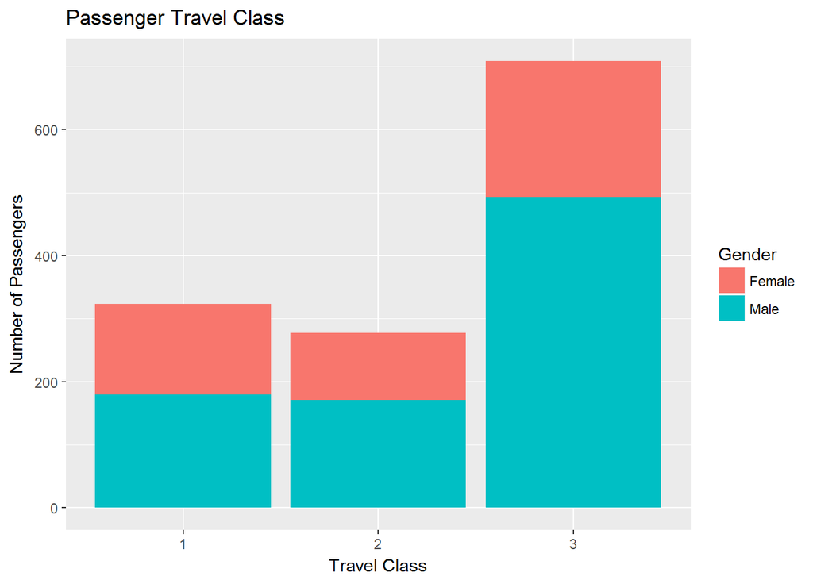

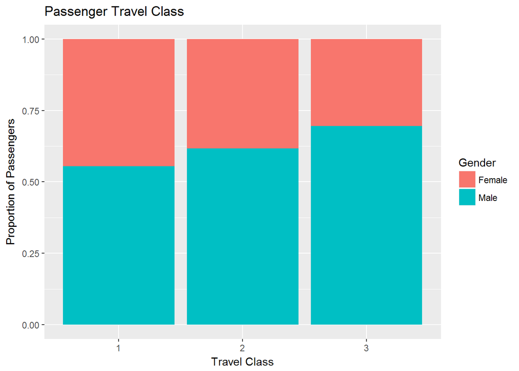

Here we notice that the greatest number of passengers were in third class, and the least number of passengers in second class. We can also see that there are more males than females within each class.

As we already noticed, most of the passengers embarked at Southampton:

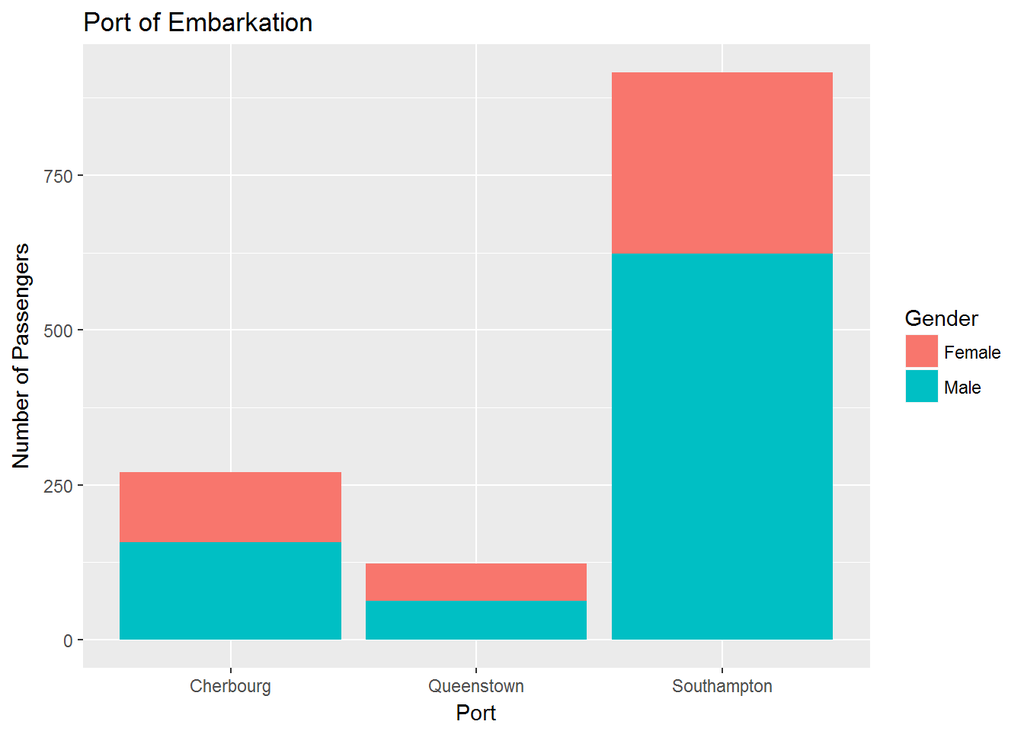

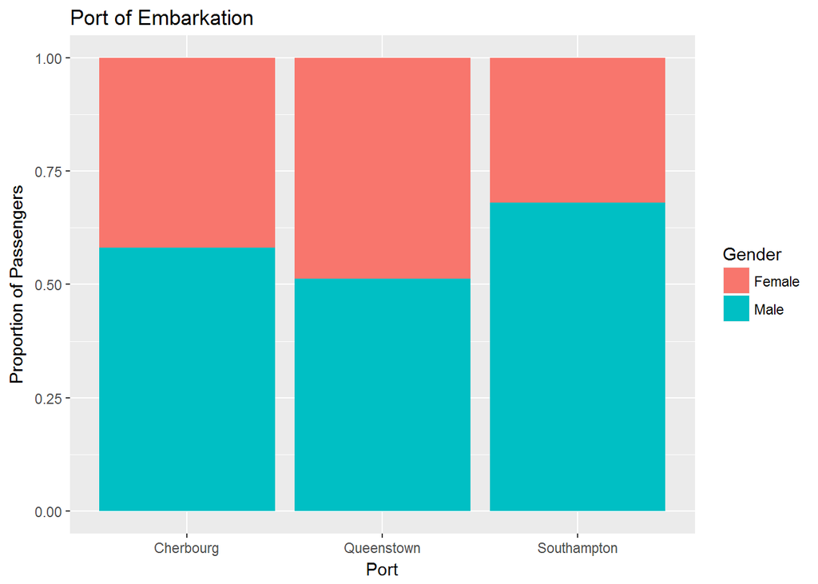

## Why so many unmarried women?

We already saw that there were more males than females on the Titanic, which isn’t unexpected. Each passenger also has a title (Mr., Mrs., etc.) and if we look at the distribution of titles among the passengers, we see something surprising:

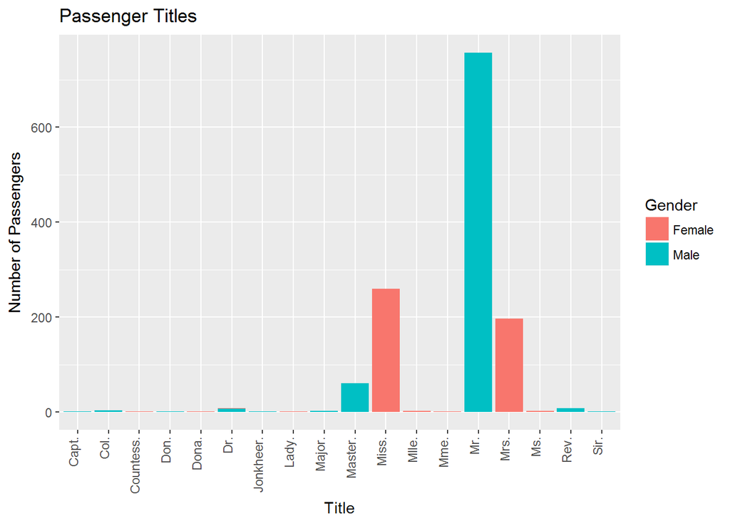

The largest group of women have the title Miss. We would expect these to be young, unmarried women traveling with their family.

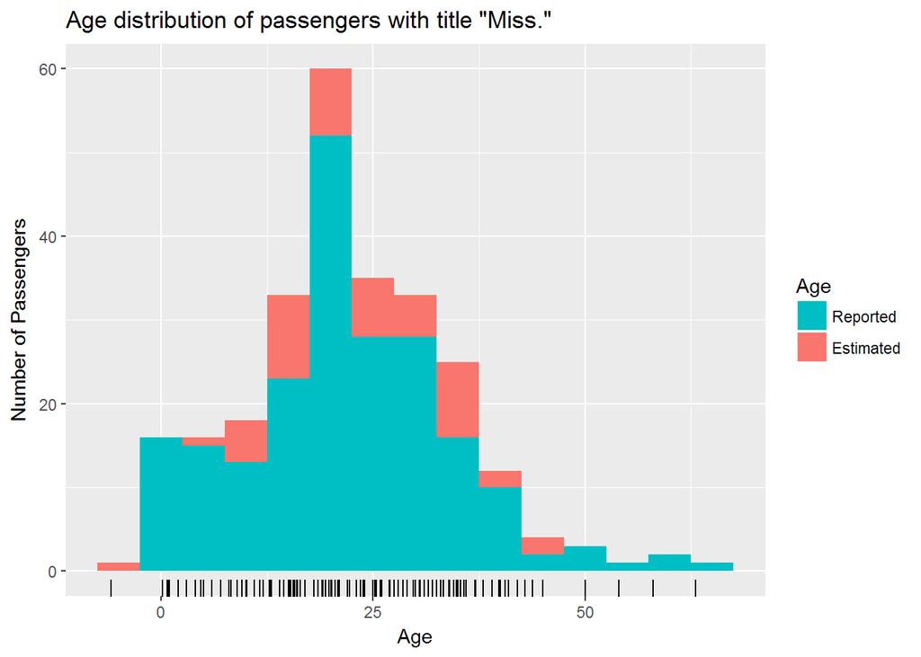

They do indeed seem to be young women with an average age of 22, with the ages < 0 due to our method of imputing missing values. Let’s look at the number of women traveling with immediate family members:

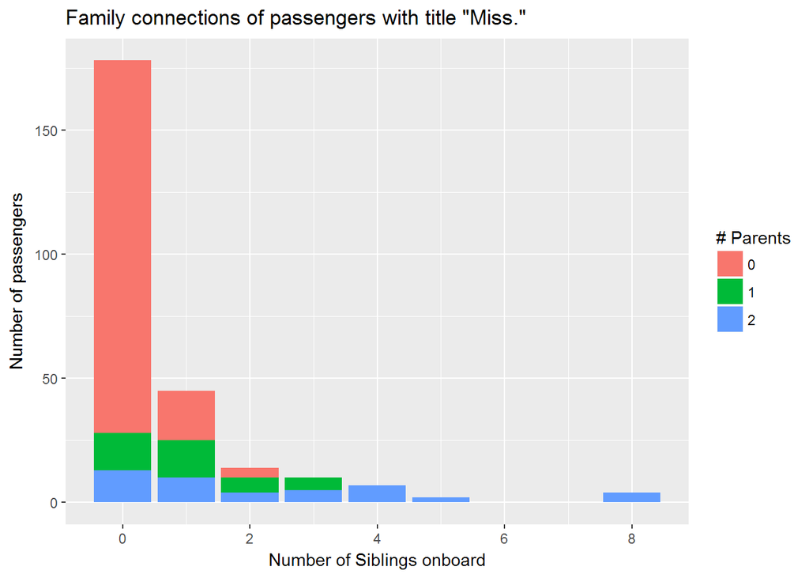

The majority of young unmarried women are not traveling with any immediate family member. At that time (1912) it seems unlikely that unmarried women would travel unaccompanied, so **who were these women traveling with?**

# Who set the ticket prices at Southampton?

We know that the airlines change ticket prices dramatically in response to consumer activity, and track our online browsing to inflate the price for trips we’re interested in. Apparently this has been going on for a long time. Consider the ticket prices paid by the Titanic Passengers:

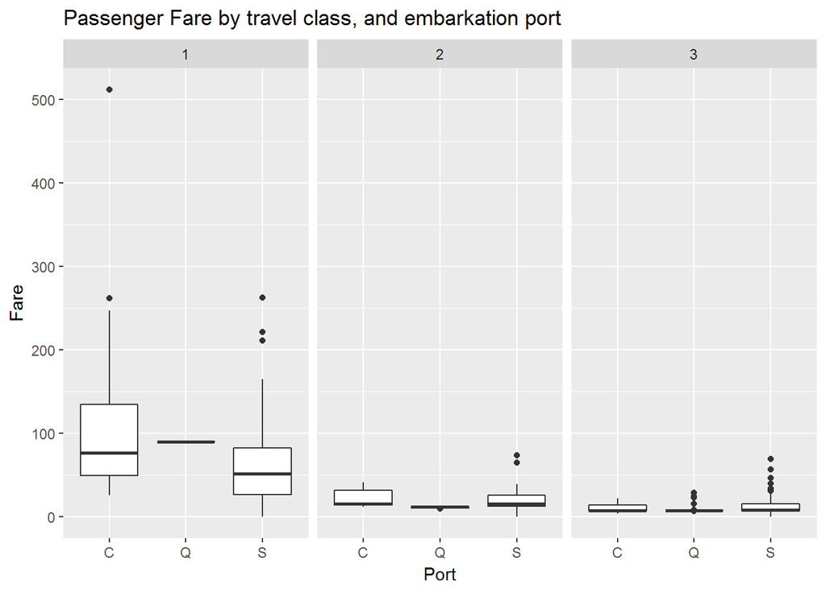

Here we see something interesting: some passengers boarding at Southampton paid more for second and third class travel than the median first class ticket from the same port. If we just look at the Southampton data, and break it down by gender:

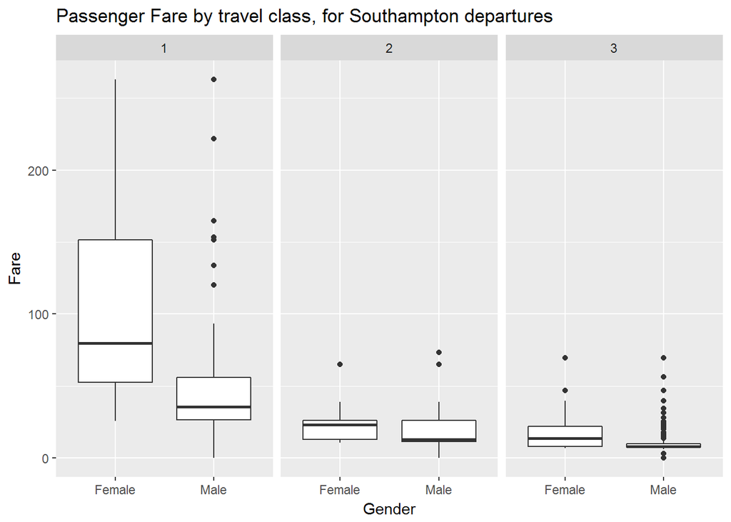

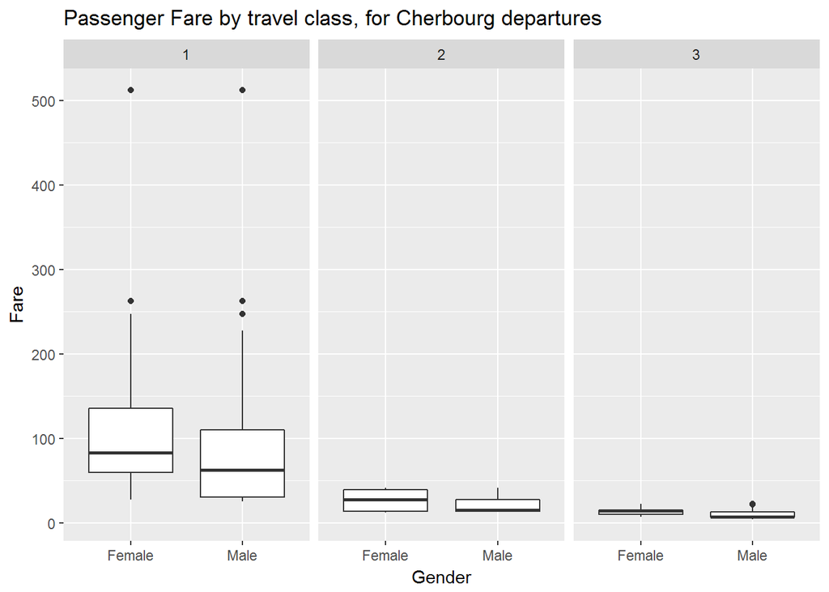

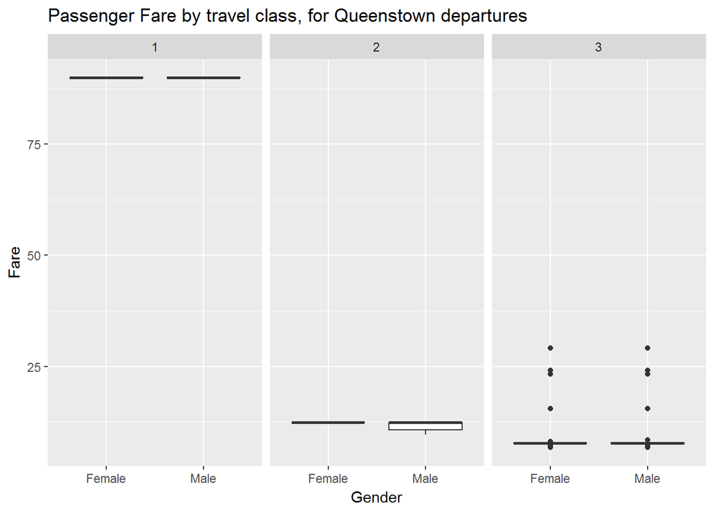

So what happened in Southampton? Perhaps looking at the fare as determined by title will help explain this:

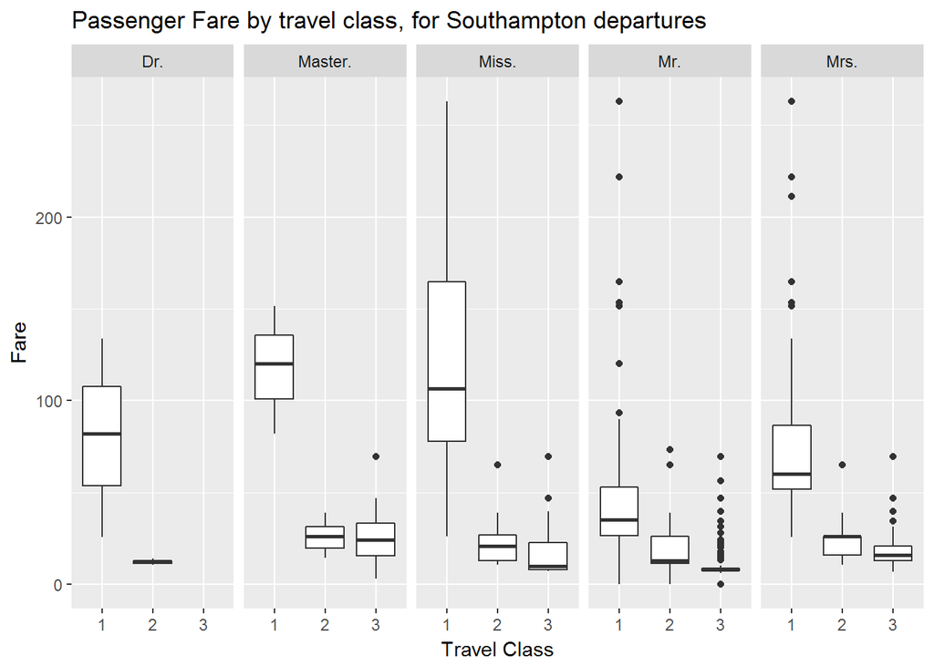

Interestingly, the group with the highest average fare is “Master”, or young boys less than 14 years old. We still see some third class passengers who paid more than many first class passengers, and inconsistent pricing within each class depending on the passenger’s title. **How were passenger fares determined?**

# Conclusions

Through this exploratory analysis, we encountered two surprising trends in the data that suggest further avenues of investigation.

1. **Ticket Prices for Southampton Departures:** While there were no obvious trends in the ticket price data, further analysis using machine learning techniques (cluster analysis, or regression models) may reveal underlying patterns.
2. **Who are the unmarried women traveling with?** There are online resources, such as the [Encyclopedia Titanica](https://www.encyclopedia-titanica.org/) that contain biographies of each passenger. A quick investigation of two unmarried women found that one was traveling with her aunt and uncle, and the other with close family friends. I suspect that this is the case for many of the young women traveling without immediate family. A future project involving text mining could investigate this further.

# What’s next?

As mentioned previously, the Titanic data set was obtained from a Kaggle competition to build a model that will predict a passenger’s survival. The next step will be to explore machine learning techniques and select an appropriate model for the passenger survival. Look for a followup project in the future.